# Collapsed Model

Author

Liam Doyle

## Description

This document is a summary of the analyses performed for the collapsed meta-analytic model conducted in Study 1 of my dissertation. This model examined the relationship between psychopathy and exploitative behavior collapsed across all economic games under study. The economic games being studied in this research were as follows:

- Prisoner’s Dilemma Game (PDG)
- Public Goods Game (PGG)
- Dictator Game (DG)
- Ultimatum Game (UG)
- Trust Game (TG)

This model utilized a multi-level or hierarchical approach in order to deal with the issue of nested effect sizes (i.e., some studies contributing more than one effect size to the analysis).

## Loading Packages

All relevant packages loaded below.

```r
library(tidyverse)
library(meta)
library(metafor)
library(devtools)
library(esc)
library(effectsize)
library(psych)
library(dmetar)
library(readxl)
```

## Loading Data

Loading the excel spreadsheet with all study information.

```r
All <- read_excel("All.xlsx")
```

## Recoding Variables as Factors

Recoding relevant variables (i.e., moderators in the analysis) as factors.

```r
All$Sample_Source <- factor(All$Sample_Source,
                            levels = c(0, 1, 2, 3),
                            labels = c("Community", "Student", "Inmate", "Mixed"))

All$Publication_Status <- factor(All$Publication_Status,
                                 levels = c(0, 1),
                                 labels = c("Unpublished", "Published"))

All$Measure_coded <- factor(All$Measure_coded,
                            levels = c(0, 1, 2, 3, 4, 5, 6),
                            labels = c("SRP", "PCL", "PPI",
                                       "LSRP", "TriPM", "SD3",
                                       "DD"))

All$Game_type <- factor(All$Game_type,
                        levels = c(0, 1, 2, 3, 4, 5, 6),
                        labels = c("All", "PGG", "DG", "UG-P", "UG-R", "TG-Trustor",
                                   "TG-Trustee"))

All$Iterated <- factor(All$Iterated,
                       levels = c(0, 1),
                       labels = c("One-shot", "Iterated"))

All$Perceived_Opponent <- factor(All$Perceived_Opponent,
                                 levels = c(0, 1),
                                 labels = c("No", "Yes"))

All$Social_role <- factor(All$Social_role,
                          levels = c(0, 1),
                          labels = c("Close member", "Distant member"))

All$Incentives <- factor(All$Incentives,
                         levels = c(0, 1, 2),
                         labels = c("Not incentivized", "Participation incentivized",
                                    "Performance incentivized"))

All$Experimental_Manipulation <- factor(All$Experimental_Manipulation,
                                        levels = c(0, 1),
                                        labels = c("No manipulation",
                                                   "Manipulation"))

All$Feedback <- factor(All$Feedback,
                       levels = c(0, 1),
                       labels = c("No feedback", "Feedback"))

All$Strategy <- factor(All$Strategy,
                       levels = c(0, 1, 2, 3, 4, 5),
                       labels = c("Live opponent", "TFT", "TF2T",
                                  "Neutral/Seesaw", "Random",
                                  "Replicator"))

All$Leniency <- factor(All$Leniency,
                       levels = c(0, 1, 2),
                       labels = c("Lenient", "Neutral", "Harsh"))
```

## Computing Additional Variables

Performing mathematical computations to compute relevant variables such as Fisher’s *z*, as well as it’s standard error and variance.

```r
All <- All %>%
  mutate(z_psyc_coop = 0.5 * log((1 + Psych_Coop)/(1 - Psych_Coop)))

All <- All %>%
  mutate(z_se_psyc_coop = 1/(sqrt(n_effect - 3)))

All <- All %>%
  mutate(var_z_psyc_coop = (z_se_psyc_coop^2))
```

## Multi-Level Random-Effects Model of Psychopathy on Cooperation Across Economic Games

As noted in the heading and the project description, this model utilizes a multi-level or hierarchical approach to modelling the relationship between psychopathy and cooperation in economic games. This is due to the fact that several of the studies included in the meta-analysis contributed more than one effect size to the analysis (e.g., a study using more than one measure of psychopathy). The contemporary recommendation for addressing this issue is to use a multi-level approach to cluster these data points - rather than simply aggregating them and ignoring potential differences between the effects.

In addition, I have made the decision to use a random-effects model for the meta-analyses in this dissertation. The fixed-effects model makes untenable assumptions about the sources of variance in the effect sizes (i.e., assuming that all effect sizes are from a homogenous population, and the only source of variance in effect sizes is from sampling error). The assumptions of a fixed-effects model also stand in contradiction to the intended moderator analyses which make up a substantial portion of our later analyses.

### Creation of the Model

```r
full.model <- rma.mv(yi = z_psyc_coop,
                     V = var_z_psyc_coop,
                     slab = Study,
                     data = All,
                     random = ~ 1 | Study/Effect_size_ID,
                     test = "t",
                     method = "REML")

summary(full.model)
```

```
Multivariate Meta-Analysis Model (k = 98; method: REML)

  logLik  Deviance       AIC       BIC      AICc
 49.4308  -98.8615  -92.8615  -85.1374  -92.6034

Variance Components:

            estim    sqrt  nlvls  fixed                factor
sigma^2.1  0.0028  0.0530     61     no                 Study
sigma^2.2  0.0084  0.0915     98     no  Study/Effect_size_ID

Test for Heterogeneity:
Q(df = 97) = 282.6380, p-val < .0001

Model Results:

estimate      se     tval  df    pval    ci.lb    ci.ub
 -0.1276  0.0159  -8.0191  97  <.0001  -0.1592  -0.0961  ***

---
Signif. codes:  0 '***' 0.001 '**' 0.01 '*' 0.05 '.' 0.1 ' ' 1
```

```r
convert_z2r(-.1276)
```

```
[1] -0.126912
```

### Distribution of Variance Across Levels

This function, provided by the package *dmetar*, calculates a multilevel version of I2. Level 1 variance corresponds to sampling error variance. Level 2 variance corresponds to within-study (or cluster) variance. Level 3 variance corresponds to between-study variance.

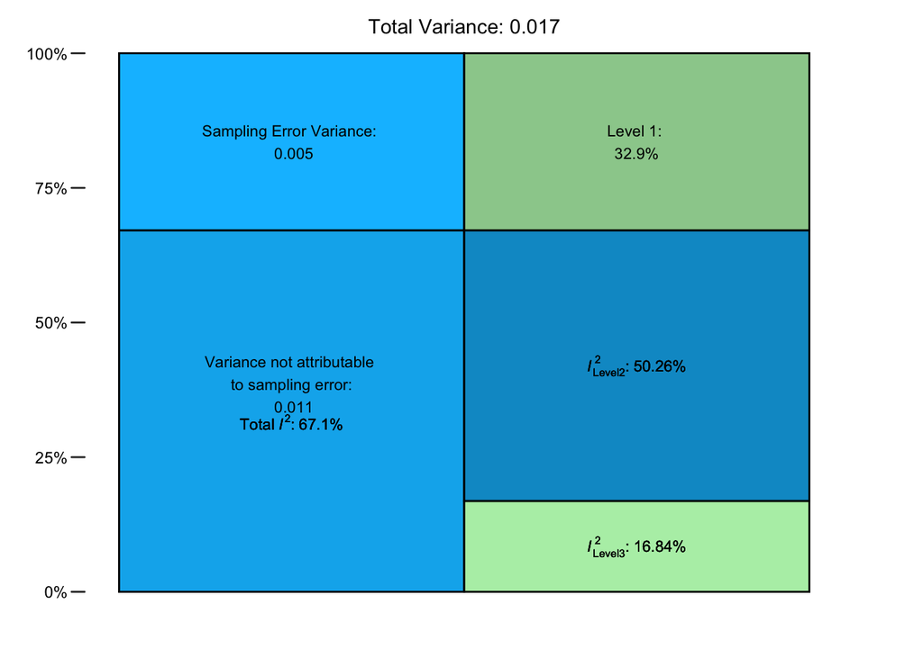

```r
i2 <- var.comp(full.model)

plot(i2)
```

In our case, roughly 67.1% of the variation between effect sizes can be attributed to within-study (50.26% of the total variation) or between-study heterogeneity (16.84%). The remaining variance has been attributed to sampling error. This *I*<sup>2</sup> value is considered to represent a moderate-to-substantial amount of heterogeneity.

### Comparing Models

```r
l3.removed <- rma.mv(yi = z_psyc_coop,
                     V = var_z_psyc_coop,
                     slab = Study,
                     data = All,
                     random = ~ 1 | Study/Effect_size_ID,
                     test = "t",
                     method = "REML",
                     sigma2 = c(0, NA))

anova(full.model, l3.removed)
```

```
        df      AIC      BIC     AICc  logLik    LRT   pval       QE
Full     3 -92.8615 -85.1374 -92.6034 49.4308               282.6380
Reduced  2 -94.2445 -89.0951 -94.1169 49.1223 0.6170 0.4322 282.6380
```

### Forest Plot of the Collapsed Model

Note: This plot had to be generated using a simple random-effects meta-analytic model, as there is not a package available in *R* to accommodate the creation of forest plots for multi-level meta-analytic models.

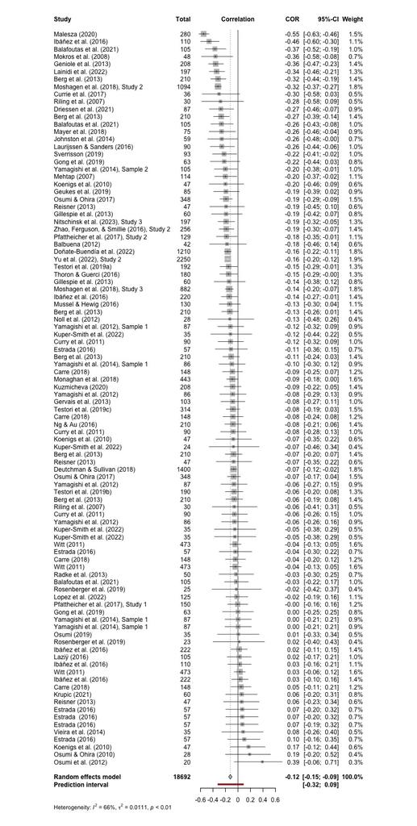

## Tests of Publication Bias

In this section, I examined the possibility of publication bias via the visual examination of funnel plots, Egger’s regression test, a simple meta-regression which regressed publication status (as a binary factor) on effect size, and PET-PEESE methods.

### Funnel Plot

While this funnel plot is asymmetric, it should be noted that we are collapsing across different economic games here. Asymmetry in a funnel plot has several possible sources (Page et al., 2020):

- Publication bias and other reporting biases;
- Variability in methodological quality;
- Between-study heterogeneity;
- Artefactual variance (i.e., via the correlation between effect sizes and their standard error)
- Chance

Given the fact that we know, at minimum, that there is substantial between-study heterogeneity due to a variety of games being represented, it is likely that this accounts for the asymmetry in the funnel plot. In other words, we are representing 7 different distributions of effects (from a fixed-effects perspective) within one funnel plot.

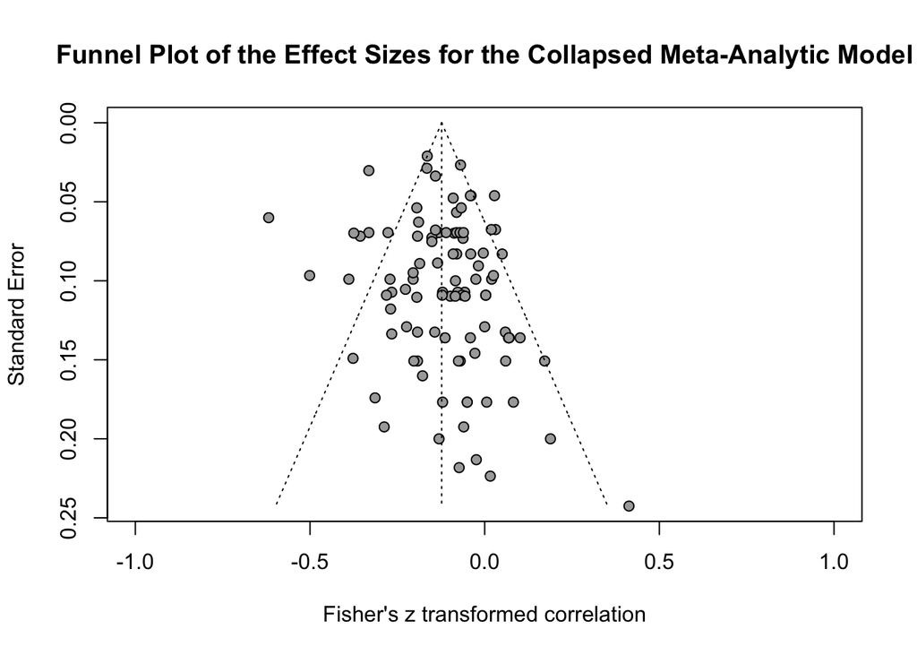

```r
meta::funnel(psyc_coop_random,
             xlim = c(-1, 1),
             studlab = FALSE)

title("Funnel Plot of the Effect Sizes for the Collapsed Meta-Analytic Model")
```

### Egger’s Regression Test

Egger’s regression test (Egger et al., 1997) is a method that provides a statistical test of asymmetry in a funnel plot. It involves the prediction of standardized effect sizes on their precision.

The intercept (i.e., $\beta_0$) is of primary interest, representing the asymmetry of the plot. NHST can be used to test the null hypothesis that the intercept is equal to zero, indicating symmetry in the funnel plot. Conversely, a rejected null hypothesis for the intercept indicates asymmetry in the funnel plot - potentially due to publication bias.

The slope (i.e., $\beta_1$) represents the effect size adjusted for precision. It is expected to be consistent with the overall meta-analytic effect.

Reported below is the significance test and parameter estimate for the intercept.

```r
metabias(psyc_coop_random,
         method.bias = "linreg")
```

```
Review:     Psychopathy and Cooperation Across All Games

Linear regression test of funnel plot asymmetry

Test result: t = 1.73, df = 96, p-value = 0.0867
Bias estimate: 0.5622 (SE = 0.3248)

Details:
- multiplicative residual heterogeneity variance (tau^2 = 2.8551)
- predictor: standard error
- weight:    inverse variance
- reference: Egger et al. (1997), BMJ
```

### Publication Status as a Moderator of Effect Size

Simple meta-regression was used to predict effect sizes from publication status as a factor (i.e., 0 = unpublished, 1 = published).

```r
mod.model.pub <- rma.mv(yi = z_psyc_coop,
                        V = var_z_psyc_coop,
                        slab = Study,
                        data = All,
                        random = ~ 1 | Study/Effect_size_ID,
                        test = "t",
                        method = "REML",
                        mods = ~ Publication_Status)


summary(mod.model.pub)
```

```
Multivariate Meta-Analysis Model (k = 98; method: REML)

   logLik   Deviance        AIC        BIC       AICc
  51.3592  -102.7185   -94.7185   -84.4611   -94.2789

Variance Components:

            estim    sqrt  nlvls  fixed                factor
sigma^2.1  0.0000  0.0000     61     no                 Study
sigma^2.2  0.0100  0.0998     98     no  Study/Effect_size_ID

Test for Residual Heterogeneity:
QE(df = 96) = 261.7328, p-val < .0001

Test of Moderators (coefficient 2):
F(df1 = 1, df2 = 96) = 6.7091, p-val = 0.0111

Model Results:

                             estimate      se     tval  df    pval    ci.lb
intrcpt                       -0.0591  0.0287  -2.0605  96  0.0421  -0.1161
Publication_StatusPublished   -0.0857  0.0331  -2.5902  96  0.0111  -0.1513
                               ci.ub
intrcpt                      -0.0022  *
Publication_StatusPublished  -0.0200  *

---
Signif. codes:  0 '***' 0.001 '**' 0.01 '*' 0.05 '.' 0.1 ' ' 1
```

### PET & PEESE Analyses

The PET (Precision-Effect Test) and PEESE (Precision-Effect Estimate with Standard Error) are two analytical methods designed to address publication bias in meta-analyses.

The former, PET analysis, is designed to determine the degree to which small-study effects and publication bias impact a meta-analysis. To do so, effect sizes are predicted from their standard errors. This analysis is used to provide evidence that a genuine effect exists beyond the effect of small-study effects/publication bias.

#### PET Analysis

The key element of the PET analysis is the estimate for $\beta_0$ or the intercept of the regression. According to the logic for PET analysis, a non-significant intercept indicates that no genuine effect occurs beyond small-study effects/publication bias. In contrast, a significant intercept provides evidence for a true effect.

That being said, one potential issue with both PET and PEESE analysis is the assumption that there is a homogenous distribution underlying effect sizes. Conceptually, this is similar to the assumption underlying fixed-effects meta-analyses (https://willgervais.com/blog/2015/6/25/putting-pet-peese-to-the-test-1). While this is problematic in and of itself, we will proceed using the PET-PEESE method.

```r
pet_model <- rma.mv(yi = z_psyc_coop,
                     V = var_z_psyc_coop,
                    mods = ~ z_se_psyc_coop,
                     slab = Study,
                     data = All,
                     random = ~ 1 | Study/Effect_size_ID,
                     test = "t",
                     method = "REML")

summary(pet_model)
```

```
Multivariate Meta-Analysis Model (k = 98; method: REML)

   logLik   Deviance        AIC        BIC       AICc
  50.5825  -101.1650   -93.1650   -82.9076   -92.7254

Variance Components:

            estim    sqrt  nlvls  fixed                factor
sigma^2.1  0.0025  0.0501     61     no                 Study
sigma^2.2  0.0084  0.0915     98     no  Study/Effect_size_ID

Test for Residual Heterogeneity:
QE(df = 96) = 274.0855, p-val < .0001

Test of Moderators (coefficient 2):
F(df1 = 1, df2 = 96) = 3.9999, p-val = 0.0483

Model Results:

                estimate      se     tval  df    pval    ci.lb    ci.ub
intrcpt          -0.1937  0.0367  -5.2818  96  <.0001  -0.2665  -0.1209  ***
z_se_psyc_coop    0.7206  0.3603   2.0000  96  0.0483   0.0054   1.4358    *

---
Signif. codes:  0 '***' 0.001 '**' 0.01 '*' 0.05 '.' 0.1 ' ' 1
```

As seen in the output, the intercept in the model is significant. This indicates that a true effect exists. According to the PET-PEESE method, we should proceed to the PEESE step of modelling.

#### PEESE Analysis

PEESE analysis aims to produce a precise estimate of the true effect size after accounting for sampling error, small-study effects, and publication bias. It does so by creating a regression where effect sizes are predicted by the squared standard errors of studies.

Again, the primary parameter estimate of interest is $\beta_0$, which indicates the estimate of the true effect size (after adjusting for sampling error, small-study effects, and publication bias). Significance tests are interpreted such that a significant intercept indicates a significant meta-analytic effect size.

A secondary parameter estimate of interest is $\beta_1$, which indicates the relationship between effect sizes and their variances. When this is significant, there is evidence that effect sizes are systematically related to the estimate of their precision (i.e., their variance), which may suggest the presence of small-study effects or publication bias.

More particularly, a positive slope indicates that larger variances (with larger standard errors, and, oftentimes, smaller sample sizes) report larger effect sizes. This is representative of the typical “small-study effect” and indicates potential publication bias.

In contrast, a negative slope suggests that smaller studies report smaller effect sizes and larger studies report larger effect sizes. This may indicate other sources of bias or sources of heterogeneity impacting the results.

```r
peese_model <- rma.mv(yi = z_psyc_coop,
                     V = var_z_psyc_coop,
                    mods = ~ var_z_psyc_coop,
                     slab = Study,
                     data = All,
                     random = ~ 1 | Study/Effect_size_ID,
                     test = "t",
                     method = "REML")

summary(peese_model)
```

```
Multivariate Meta-Analysis Model (k = 98; method: REML)

   logLik   Deviance        AIC        BIC       AICc
  51.1620  -102.3240   -94.3240   -84.0666   -93.8844

Variance Components:

            estim    sqrt  nlvls  fixed                factor
sigma^2.1  0.0026  0.0514     61     no                 Study
sigma^2.2  0.0081  0.0901     98     no  Study/Effect_size_ID

Test for Residual Heterogeneity:
QE(df = 96) = 272.9570, p-val < .0001

Test of Moderators (coefficient 2):
F(df1 = 1, df2 = 96) = 4.9290, p-val = 0.0288

Model Results:

                 estimate      se     tval  df    pval    ci.lb    ci.ub
intrcpt           -0.1647  0.0229  -7.1931  96  <.0001  -0.2101  -0.1192  ***
var_z_psyc_coop    3.5769  1.6111   2.2201  96  0.0288   0.3789   6.7750    *

---
Signif. codes:  0 '***' 0.001 '**' 0.01 '*' 0.05 '.' 0.1 ' ' 1
```

```r
convert_z2r(-.1647)
```

```
[1] -0.1632268
```

As seen in the model output, the PEESE method indicates that the true effect size is *r* = -.163 and significant at *p* < .0001.

The slope coefficient indicates a positive, significant relationship between effect sizes and their variances (see above). Given the fact that it is a positive relationship, it indicates publication bias according to the logic of the model. However, the most likely reason for this result is a violation of one of the assumptions of the analyses - the fact that effect sizes come from a homogeneous distribution of effects. As we know, the collapsed model instead represents effect sizes drawn from several different distributions. We know this both from our knowledge of existing between-studies heterogeneity (i.e., via different economic games) as well as a more broad understanding of the tenability of fixed vs. random effects meta-analyses. Furthermore, PET-PEESE analyses has been known to perform poorly as between-study heterogeneity increases, and this meta-analytic model has an *I*<sup>2</sup> value of 67.1%.

To illustrate the slope estimated by the model visually, we will plot the regression.

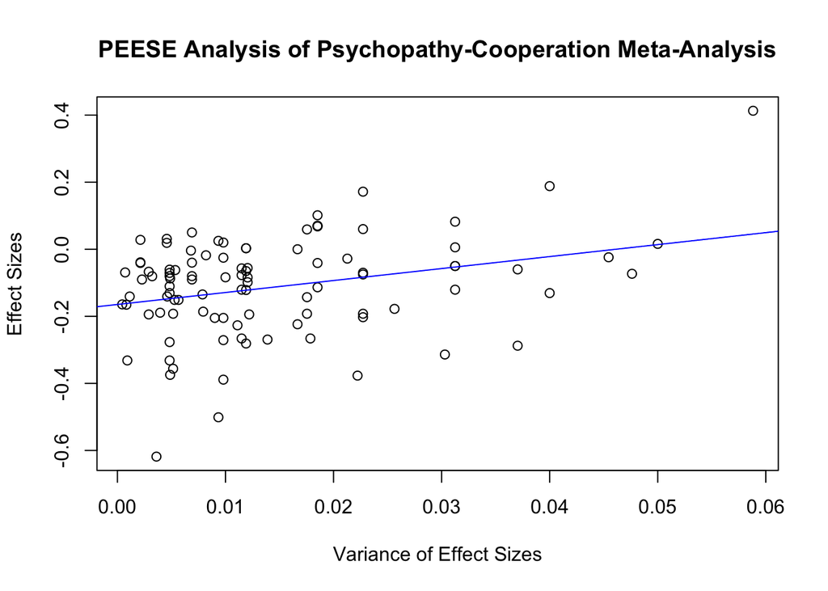

```r
plot(
  All$var_z_psyc_coop, All$z_psyc_coop,
  xlab = "Variance of Effect Sizes",
  ylab = "Effect Sizes",
  main = "PEESE Analysis of Psychopathy-Cooperation Meta-Analysis"
)
abline(a = coef(peese_model)[1], b = coef(peese_model)[2], col = "blue")
```

### Fail-Safe *N*

A variation of Orwin’s (1983) fail-safe N test was used to indicate the number of studies with null effects needed to reduce the effect size to a practically irrelevant size (Viechtbauer, 2010). Practical insignificance was demarked by an effect size of r = |.05|, depending on the direction of the summary effect.

```r
fail.safe <- rma(yi = z_psyc_coop,
                 vi = var_z_psyc_coop,
                 slab = Study,
                 data = All,
                 test = "t",
                 method = "REML")

fsn(fail.safe, type = "General", target = 0.05)
```

```
Fail-safe N Calculation Using the General Approach

Average Effect Size:         -0.1231 (with file drawer: -0.0501)
Amount of Heterogeneity:      0.0111 (with file drawer:  0.0148)
Observed Significance Level:  <.0001 (with file drawer:  <.0001)
Target Effect Size:          -0.0500

Fail-safe N: 112
```

## Moderator Analysis

Afterwards, a series of moderators were tested. The list of moderators was generated *a priori* using the Affordance-Based Framework of Prosocial Behavior, original ideas, and ideas from previous meta-analyses on psychopathy and cooperation (e.g., Thielmann et al., 2020). In-depth reasoning for the selection of moderators is provided in the dissertation package.

Multiple meta-regression was not used in our study due to constraints arising from (a) a smaller numbers of studies being used (b) the large number of moderators being considered (Higgins & Thompson, 2004). As such, our study explored individual moderators with simple meta-regression analysis. For each model where there were over 10 studies (Deeks et al., 2023), moderators of interest were examined individually using simple meta-regression.

As the current model had 98 effect sizes, simple meta-regression was used to test the list of moderators. The results are shown below.

### *N* as a Moderator of Effect Size

```r
mod.model.n <- rma.mv(yi = z_psyc_coop,
                             V = var_z_psyc_coop,
                             slab = Study,
                             data = All,
                             random = ~ 1 | Study/Effect_size_ID,
                             test = "t",
                             method = "REML",
                             mods = ~ n_effect)


summary(mod.model.n)
```

```
Multivariate Meta-Analysis Model (k = 98; method: REML)

  logLik  Deviance       AIC       BIC      AICc
 48.5952  -97.1904  -89.1904  -78.9330  -88.7509

Variance Components:

            estim    sqrt  nlvls  fixed                factor
sigma^2.1  0.0026  0.0512     61     no                 Study
sigma^2.2  0.0087  0.0932     98     no  Study/Effect_size_ID

Test for Residual Heterogeneity:
QE(df = 96) = 278.3671, p-val < .0001

Test of Moderators (coefficient 2):
F(df1 = 1, df2 = 96) = 0.7901, p-val = 0.3763

Model Results:

          estimate      se     tval  df    pval    ci.lb    ci.ub
intrcpt    -0.1177  0.0192  -6.1186  96  <.0001  -0.1559  -0.0795  ***
n_effect   -0.0000  0.0000  -0.8888  96  0.3763  -0.0001   0.0000

---
Signif. codes:  0 '***' 0.001 '**' 0.01 '*' 0.05 '.' 0.1 ' ' 1
```

### Sex Composition as a Moderator of Effect Size

Note: sex composition was a variable represented as the proportion of participants who identified as female in the study.

```r
mod.model.sex <- rma.mv(yi = z_psyc_coop,
                        V = var_z_psyc_coop,
                        slab = Study,
                        data = All,
                        random = ~ 1 | Study/Effect_size_ID,
                        test = "t",
                        method = "REML",
                        mods = ~ Sex_female)
summary(mod.model.sex)
```

```
Multivariate Meta-Analysis Model (k = 96; method: REML)

  logLik  Deviance       AIC       BIC      AICc
 46.4521  -92.9043  -84.9043  -74.7311  -84.4548

Variance Components:

            estim    sqrt  nlvls  fixed                factor
sigma^2.1  0.0036  0.0596     59     no                 Study
sigma^2.2  0.0083  0.0912     96     no  Study/Effect_size_ID

Test for Residual Heterogeneity:
QE(df = 94) = 278.3138, p-val < .0001

Test of Moderators (coefficient 2):
F(df1 = 1, df2 = 94) = 0.1994, p-val = 0.6562

Model Results:

            estimate      se     tval  df    pval    ci.lb    ci.ub
intrcpt      -0.1149  0.0349  -3.2927  94  0.0014  -0.1842  -0.0456  **
Sex_female   -0.0292  0.0654  -0.4465  94  0.6562  -0.1591   0.1007

---
Signif. codes:  0 '***' 0.001 '**' 0.01 '*' 0.05 '.' 0.1 ' ' 1
```

### Mean Age as a Moderator of Effect Size

```r
mod.model.age <- rma.mv(yi = z_psyc_coop,
                        V = var_z_psyc_coop,
                        slab = Study,
                        data = All,
                        random = ~ 1 | Study/Effect_size_ID,
                        test = "t",
                        method = "REML",
                        mods = ~ Age)
summary(mod.model.age)
```

```
Multivariate Meta-Analysis Model (k = 80; method: REML)

  logLik  Deviance       AIC       BIC      AICc
 34.6252  -69.2504  -61.2504  -51.8235  -60.7024

Variance Components:

            estim    sqrt  nlvls  fixed                factor
sigma^2.1  0.0021  0.0463     51     no                 Study
sigma^2.2  0.0113  0.1062     80     no  Study/Effect_size_ID

Test for Residual Heterogeneity:
QE(df = 78) = 242.8898, p-val < .0001

Test of Moderators (coefficient 2):
F(df1 = 1, df2 = 78) = 0.5049, p-val = 0.4795

Model Results:

         estimate      se     tval  df    pval    ci.lb   ci.ub
intrcpt   -0.0913  0.0648  -1.4101  78  0.1625  -0.2202  0.0376
Age       -0.0017  0.0023  -0.7105  78  0.4795  -0.0063  0.0030

---
Signif. codes:  0 '***' 0.001 '**' 0.01 '*' 0.05 '.' 0.1 ' ' 1
```

### Sample Source as a Moderator of Effect Size

Note: Studies were coded such that:

- 0 = Community;
- 1 = Student;
- 2 = Inmate;
- 3 = Mixed

```r
mod.model.sample <- rma.mv(yi = z_psyc_coop,
                           V = var_z_psyc_coop,
                           slab = Study,
                           data = All,
                           random = ~ 1 | Study/Effect_size_ID,
                           test = "t",
                           method = "REML",
                           mods = ~ Sample_Source)
summary(mod.model.sample)
```

```
Multivariate Meta-Analysis Model (k = 95; method: REML)

  logLik  Deviance       AIC       BIC      AICc
 45.4454  -90.8909  -78.8909  -63.8257  -77.8909

Variance Components:

            estim    sqrt  nlvls  fixed                factor
sigma^2.1  0.0040  0.0631     58     no                 Study
sigma^2.2  0.0079  0.0888     95     no  Study/Effect_size_ID

Test for Residual Heterogeneity:
QE(df = 91) = 266.6817, p-val < .0001

Test of Moderators (coefficients 2:4):
F(df1 = 3, df2 = 91) = 1.2674, p-val = 0.2903

Model Results:

                      estimate      se     tval  df    pval    ci.lb    ci.ub
intrcpt                -0.1491  0.0272  -5.4852  91  <.0001  -0.2031  -0.0951
Sample_SourceStudent    0.0412  0.0362   1.1391  91  0.2576  -0.0306   0.1130
Sample_SourceInmate     0.0385  0.0642   0.5994  91  0.5504  -0.0891   0.1660
Sample_SourceMixed     -0.1665  0.1241  -1.3417  91  0.1830  -0.4131   0.0800

intrcpt               ***
Sample_SourceStudent
Sample_SourceInmate
Sample_SourceMixed

---
Signif. codes:  0 '***' 0.001 '**' 0.01 '*' 0.05 '.' 0.1 ' ' 1
```

### Psychopathy Measure as a Moderator of Effect Size

Note: Studies were coded such that:

- 0 = SRP;
- 1 = PCL;
- 2 = PPI;
- 3 = LSRP;
- 4 = TriPM;
- 5 = SD3;
- 6 = DD

```r
mod.model.measure <- rma.mv(yi = z_psyc_coop,
                            V = var_z_psyc_coop,
                            slab = Study,
                            data = All,
                            random = ~ 1 | Study/Effect_size_ID,
                            test = "t",
                            method = "REML",
                            mods = ~ Measure_coded)
summary(mod.model.measure)
```

```
Multivariate Meta-Analysis Model (k = 95; method: REML)

  logLik  Deviance       AIC       BIC      AICc
 42.2424  -84.4847  -66.4847  -44.1887  -64.1770

Variance Components:

            estim    sqrt  nlvls  fixed                factor
sigma^2.1  0.0036  0.0598     58     no                 Study
sigma^2.2  0.0090  0.0950     95     no  Study/Effect_size_ID

Test for Residual Heterogeneity:
QE(df = 88) = 273.0666, p-val < .0001

Test of Moderators (coefficients 2:7):
F(df1 = 6, df2 = 88) = 0.5026, p-val = 0.8048

Model Results:

                    estimate      se     tval  df    pval    ci.lb    ci.ub
intrcpt              -0.1265  0.0366  -3.4517  88  0.0009  -0.1993  -0.0537
Measure_codedPCL      0.0776  0.0808   0.9602  88  0.3396  -0.0830   0.2382
Measure_codedPPI     -0.0069  0.0514  -0.1347  88  0.8932  -0.1091   0.0953
Measure_codedLSRP    -0.0100  0.0485  -0.2057  88  0.8375  -0.1064   0.0865
Measure_codedTriPM    0.0538  0.0936   0.5748  88  0.5669  -0.1322   0.2398
Measure_codedSD3      0.0144  0.0548   0.2629  88  0.7933  -0.0945   0.1233
Measure_codedDD      -0.0679  0.0712  -0.9535  88  0.3430  -0.2094   0.0736

intrcpt             ***
Measure_codedPCL
Measure_codedPPI
Measure_codedLSRP
Measure_codedTriPM
Measure_codedSD3
Measure_codedDD

---
Signif. codes:  0 '***' 0.001 '**' 0.01 '*' 0.05 '.' 0.1 ' ' 1
```

### Economic Game as a Moderator of Effect Size

Note: Studies were coded such that:

- 0 = PDG;
- 1 = PGG;
- 2 = DG;
- 3 = UG-P;
- 4 = UG-R;
- 5 = TG-P;
- 6 = TG-R

```r
mod.model.game <- rma.mv(yi = z_psyc_coop,
                            V = var_z_psyc_coop,
                            slab = Study,
                            data = All,
                            random = ~ 1 | Study/Effect_size_ID,
                            test = "t",
                            method = "REML",
                            mods = ~ Game_type)

summary(mod.model.game)
```

```
Multivariate Meta-Analysis Model (k = 98; method: REML)

   logLik   Deviance        AIC        BIC       AICc
  51.2072  -102.4143   -84.4143   -61.8166   -82.1921

Variance Components:

            estim    sqrt  nlvls  fixed                factor
sigma^2.1  0.0034  0.0583     61     no                 Study
sigma^2.2  0.0062  0.0785     98     no  Study/Effect_size_ID

Test for Residual Heterogeneity:
QE(df = 91) = 229.2091, p-val < .0001

Test of Moderators (coefficients 2:7):
F(df1 = 6, df2 = 91) = 2.7710, p-val = 0.0161

Model Results:

                     estimate      se     tval  df    pval    ci.lb    ci.ub
intrcpt               -0.1524  0.0254  -6.0035  91  <.0001  -0.2029  -0.1020
Game_typePGG           0.0664  0.0589   1.1271  91  0.2627  -0.0507   0.1835
Game_typeDG           -0.0130  0.0362  -0.3602  91  0.7196  -0.0850   0.0589
Game_typeUG-P          0.0905  0.0517   1.7504  91  0.0834  -0.0122   0.1932
Game_typeUG-R          0.1069  0.0449   2.3808  91  0.0194   0.0177   0.1961
Game_typeTG-Trustor    0.1537  0.0755   2.0354  91  0.0447   0.0037   0.3038
Game_typeTG-Trustee   -0.0536  0.0594  -0.9034  91  0.3687  -0.1715   0.0643

intrcpt              ***
Game_typePGG
Game_typeDG
Game_typeUG-P          .
Game_typeUG-R          *
Game_typeTG-Trustor    *
Game_typeTG-Trustee

---
Signif. codes:  0 '***' 0.001 '**' 0.01 '*' 0.05 '.' 0.1 ' ' 1
```

### One-Shot vs. Iterated as a Moderator of Effect Size

Note: Studies were coded such that:

- 0 = one-shot;
- 1 = iterated

```r
mod.model.iterated <- rma.mv(yi = z_psyc_coop,
                             V = var_z_psyc_coop,
                             slab = Study,
                             data = All,
                             random = ~ 1 | Study/Effect_size_ID,
                             test = "t",
                             method = "REML",
                             mods = ~ Iterated)
summary(mod.model.iterated)
```

```
Multivariate Meta-Analysis Model (k = 96; method: REML)

   logLik   Deviance        AIC        BIC       AICc
  50.0738  -100.1477   -92.1477   -81.9745   -91.6982

Variance Components:

            estim    sqrt  nlvls  fixed                factor
sigma^2.1  0.0000  0.0000     61     no                 Study
sigma^2.2  0.0102  0.1008     96     no  Study/Effect_size_ID

Test for Residual Heterogeneity:
QE(df = 94) = 262.7644, p-val < .0001

Test of Moderators (coefficient 2):
F(df1 = 1, df2 = 94) = 2.5026, p-val = 0.1170

Model Results:

                  estimate      se     tval  df    pval    ci.lb    ci.ub
intrcpt            -0.1096  0.0166  -6.6114  94  <.0001  -0.1425  -0.0767  ***
IteratedIterated   -0.0536  0.0339  -1.5820  94  0.1170  -0.1210   0.0137

---
Signif. codes:  0 '***' 0.001 '**' 0.01 '*' 0.05 '.' 0.1 ' ' 1
```

### Perceived Opponent as a Moderator of Effect Size

Note: Studies were coded such that:

- 0 = participants were *not* led to believe that their opponent was human;
- 1 = participants *were* led to believe that their opponent was human

```r
mod.model.perceive <- rma.mv(yi = z_psyc_coop,
                             V = var_z_psyc_coop,
                             slab = Study,
                             data = All,
                             random = ~ 1 | Study/Effect_size_ID,
                             test = "t",
                             method = "REML",
                             mods = ~ Perceived_Opponent)
summary(mod.model.perceive)
```

```
Multivariate Meta-Analysis Model (k = 93; method: REML)

  logLik  Deviance       AIC       BIC      AICc
 48.9663  -97.9326  -89.9326  -79.8891  -89.4675

Variance Components:

            estim    sqrt  nlvls  fixed                factor
sigma^2.1  0.0000  0.0000     58     no                 Study
sigma^2.2  0.0099  0.0997     93     no  Study/Effect_size_ID

Test for Residual Heterogeneity:
QE(df = 91) = 236.7699, p-val < .0001

Test of Moderators (coefficient 2):
F(df1 = 1, df2 = 91) = 6.5032, p-val = 0.0124

Model Results:

                       estimate      se     tval  df    pval    ci.lb    ci.ub
intrcpt                 -0.1856  0.0291  -6.3818  91  <.0001  -0.2434  -0.1278
Perceived_OpponentYes    0.0858  0.0336   2.5501  91  0.0124   0.0190   0.1526

intrcpt                ***
Perceived_OpponentYes    *

---
Signif. codes:  0 '***' 0.001 '**' 0.01 '*' 0.05 '.' 0.1 ' ' 1
```

### Social Role of Opponent as a Moderator of Effect Size

Note: Studies were coded such that:

- 0 = The participants’ perceived opponent was a close member of their social circle (e.g., friend, in-group member);
- 1 = The participants’ perceived opponent was a distant member of their social circle (e.g., stranger, out-group member)

```r
mod.model.social <- rma.mv(yi = z_psyc_coop,
                           V = var_z_psyc_coop,
                           slab = Study,
                           data = All,
                           random = ~ 1 | Study/Effect_size_ID,
                           test = "t",
                           method = "REML",
                           mods = ~ Social_role)
summary(mod.model.social)
```

```
Multivariate Meta-Analysis Model (k = 76; method: REML)

  logLik  Deviance       AIC       BIC      AICc
 36.3742  -72.7484  -64.7484  -55.5322  -64.1687

Variance Components:

            estim    sqrt  nlvls  fixed                factor
sigma^2.1  0.0000  0.0000     50     no                 Study
sigma^2.2  0.0120  0.1096     76     no  Study/Effect_size_ID

Test for Residual Heterogeneity:
QE(df = 74) = 238.3621, p-val < .0001

Test of Moderators (coefficient 2):
F(df1 = 1, df2 = 74) = 0.6280, p-val = 0.4306

Model Results:

                           estimate      se     tval  df    pval    ci.lb
intrcpt                     -0.0542  0.0684  -0.7913  74  0.4313  -0.1906
Social_roleDistant member   -0.0560  0.0707  -0.7925  74  0.4306  -0.1969
                            ci.ub
intrcpt                    0.0822
Social_roleDistant member  0.0848

---
Signif. codes:  0 '***' 0.001 '**' 0.01 '*' 0.05 '.' 0.1 ' ' 1
```

### Incentive Structure as a Moderator of Effect Size

Note: Studies were coded such that:

- 0 = The study was not incentivized;
- 1 = Participation was incentivized;
- 2 = Performance was incentivized

```r
mod.model.incentive <- rma.mv(yi = z_psyc_coop,
                              V = var_z_psyc_coop,
                              slab = Study,
                              data = All,
                              random = ~ 1 | Study/Effect_size_ID,
                              test = "t",
                              method = "REML",
                              mods = ~ Incentives)
summary(mod.model.incentive)
```

```
Multivariate Meta-Analysis Model (k = 85; method: REML)

  logLik  Deviance       AIC       BIC      AICc
 49.8630  -99.7259  -89.7259  -77.6923  -88.9364

Variance Components:

            estim    sqrt  nlvls  fixed                factor
sigma^2.1  0.0000  0.0000     54     no                 Study
sigma^2.2  0.0079  0.0887     85     no  Study/Effect_size_ID

Test for Residual Heterogeneity:
QE(df = 82) = 189.4420, p-val < .0001

Test of Moderators (coefficients 2:3):
F(df1 = 2, df2 = 82) = 7.4531, p-val = 0.0011

Model Results:

                                      estimate      se     tval  df    pval
intrcpt                                -0.2601  0.0430  -6.0533  82  <.0001
IncentivesParticipation incentivized    0.1098  0.0501   2.1905  82  0.0313
IncentivesPerformance incentivized      0.1721  0.0467   3.6826  82  0.0004
                                        ci.lb    ci.ub
intrcpt                               -0.3456  -0.1746  ***
IncentivesParticipation incentivized   0.0101   0.2095    *
IncentivesPerformance incentivized     0.0791   0.2651  ***

---
Signif. codes:  0 '***' 0.001 '**' 0.01 '*' 0.05 '.' 0.1 ' ' 1
```

### Feedback as a Moderator of Effect Size

Note: Studies were coded such that:

- 0 = Participants did not receive feedback on their choices (i.e., what their opponent chose to do, what the outcome was);
- 1 = Participants did receive feedback on their choices

```r
mod.model.feedback <- rma.mv(yi = z_psyc_coop,
                             V = var_z_psyc_coop,
                             slab = Study,
                             data = All,
                             random = ~ 1 | Study/Effect_size_ID,
                             test = "t",
                             method = "REML",
                             mods = ~ Feedback)
summary(mod.model.feedback)
```

```
Multivariate Meta-Analysis Model (k = 41; method: REML)

  logLik  Deviance       AIC       BIC      AICc
 15.6225  -31.2449  -23.2449  -16.5907  -22.0684

Variance Components:

            estim    sqrt  nlvls  fixed                factor
sigma^2.1  0.0053  0.0731     29     no                 Study
sigma^2.2  0.0117  0.1081     41     no  Study/Effect_size_ID

Test for Residual Heterogeneity:
QE(df = 39) = 134.7389, p-val < .0001

Test of Moderators (coefficient 2):
F(df1 = 1, df2 = 39) = 1.0678, p-val = 0.3078

Model Results:

                  estimate      se     tval  df    pval    ci.lb   ci.ub
intrcpt            -0.0846  0.0420  -2.0147  39  0.0509  -0.1695  0.0003  .
FeedbackFeedback   -0.0588  0.0569  -1.0333  39  0.3078  -0.1738  0.0563

---
Signif. codes:  0 '***' 0.001 '**' 0.01 '*' 0.05 '.' 0.1 ' ' 1
```

### Opponent Strategy as a Moderator of Effect Size

Note: Studies were coded such that:

- 0 = Live opponent;
- 1 = TFT;
- 2 = TF2T;
- 3 = Neutral/SeeSaw;
- 4 = Random;
- 5 = Replicator

```r
mod.model.strategy <- rma.mv(yi = z_psyc_coop,
                             V = var_z_psyc_coop,
                             slab = Study,
                             data = All,
                             random = ~ 1 | Study/Effect_size_ID,
                             test = "t",
                             method = "REML",
                             mods = ~ Strategy)
summary(mod.model.strategy)
```

```
Multivariate Meta-Analysis Model (k = 32; method: REML)

  logLik  Deviance       AIC       BIC      AICc
 16.8547  -33.7094  -19.7094  -10.6386  -13.8147

Variance Components:

            estim    sqrt  nlvls  fixed                factor
sigma^2.1  0.0073  0.0855     24     no                 Study
sigma^2.2  0.0000  0.0000     32     no  Study/Effect_size_ID

Test for Residual Heterogeneity:
QE(df = 27) = 38.5922, p-val = 0.0690

Test of Moderators (coefficients 2:5):
F(df1 = 4, df2 = 27) = 1.2927, p-val = 0.2977

Model Results:

                        estimate      se     tval  df    pval    ci.lb    ci.ub
intrcpt                  -0.1159  0.0332  -3.4918  27  0.0017  -0.1841  -0.0478
StrategyTFT              -0.0078  0.0820  -0.0951  27  0.9250  -0.1761   0.1605
StrategyTF2T             -0.0374  0.0739  -0.5063  27  0.6168  -0.1891   0.1142
StrategyNeutral/Seesaw   -0.1980  0.1968  -1.0061  27  0.3233  -0.6017   0.2058
StrategyReplicator       -0.2404  0.1165  -2.0636  27  0.0488  -0.4795  -0.0014

intrcpt                 **
StrategyTFT
StrategyTF2T
StrategyNeutral/Seesaw
StrategyReplicator       *

---
Signif. codes:  0 '***' 0.001 '**' 0.01 '*' 0.05 '.' 0.1 ' ' 1
```

### Opponent Leniency as a Moderator of Effect Size

Note: Studies were coded such that:

- 0 = Lenient (e.g., Always Cooperate, TF2T, TF3T);
- 1 = Neutral (e.g., TFT, Win-Stay, Lose-Shift);
- 2 = Harsh (e.g., Always Defect, Grim, 2TFT)

```r
mod.model.leniency <- rma.mv(yi = z_psyc_coop,
                             V = var_z_psyc_coop,
                             slab = Study,
                             data = All,
                             random = ~ 1 | Study/Effect_size_ID,
                             test = "t",
                             method = "REML",
                             mods = ~ Leniency)
summary(mod.model.leniency)
```

```
Multivariate Meta-Analysis Model (k = 13; method: REML)

  logLik  Deviance       AIC       BIC      AICc
  5.8540  -11.7081   -3.7081   -2.1165    2.9586

Variance Components:

            estim    sqrt  nlvls  fixed                factor
sigma^2.1  0.0002  0.0137      9     no                 Study
sigma^2.2  0.0000  0.0000     13     no  Study/Effect_size_ID

Test for Residual Heterogeneity:
QE(df = 11) = 9.1154, p-val = 0.6112

Test of Moderators (coefficient 2):
F(df1 = 1, df2 = 11) = 0.0122, p-val = 0.9141

Model Results:

                 estimate      se     tval  df    pval    ci.lb    ci.ub
intrcpt           -0.1307  0.0428  -3.0534  11  0.0110  -0.2249  -0.0365  *
LeniencyNeutral   -0.0078  0.0710  -0.1103  11  0.9141  -0.1640   0.1483

---
Signif. codes:  0 '***' 0.001 '**' 0.01 '*' 0.05 '.' 0.1 ' ' 1
```